# **Atelier R** Cartographie

Kim Antunez, Etienne Côme

QuantiLille** Juin 2021

# L’écosystème spatial sur R

## `sf` pour Simple Features

- Site web de `sf`: [Simple Features for R](https://r-spatial.github.io/sf/index.html)
- Sortie en octobre 2016
- A pour but de rassembler les fonctionnalités d’anciens packages (`sp`, `rgeos` and `rgdal`) en un seul
- Facilite la manipulation de données spatiales, avec des objets simples.
- [Tidy data](http://vita.had.co.nz/papers/tidy-data.html): compatible avec la syntaxe pipe `%>%` et les opérateurs du `tidyverse`.
- Principal auteur et mainteneur : Edzer Pebesma (également auteur du package `sp`)

## Utiliser `sf`

### Importer les données

```r
library(sf)
mtq <- st_read("data/mtq/martinique.shp")
```

### Projection

Obtenir la projection en utilisant `st_crs()` ([code epsg](https://epsg.io/)) et la modifier en utilisant `st_transform()`.

```r
st_crs(mtq)
```

```
Coordinate Reference System:
  User input: WGS 84 / UTM zone 20N
  wkt:
PROJCRS["WGS 84 / UTM zone 20N",
    BASEGEOGCRS["WGS 84",
        DATUM["World Geodetic System 1984",
            ELLIPSOID["WGS 84",6378137,298.257223563,
                LENGTHUNIT["metre",1]]],
        PRIMEM["Greenwich",0,
            ANGLEUNIT["degree",0.0174532925199433]],
        ID["EPSG",4326]],
    CONVERSION["UTM zone 20N",
        METHOD["Transverse Mercator",
            ID["EPSG",9807]],
        PARAMETER["Latitude of natural origin",0,
            ANGLEUNIT["Degree",0.0174532925199433],
            ID["EPSG",8801]],
        PARAMETER["Longitude of natural origin",-63,
            ANGLEUNIT["Degree",0.0174532925199433],
            ID["EPSG",8802]],
        PARAMETER["Scale factor at natural origin",0.9996,
            SCALEUNIT["unity",1],
            ID["EPSG",8805]],
        PARAMETER["False easting",500000,
            LENGTHUNIT["metre",1],
            ID["EPSG",8806]],
        PARAMETER["False northing",0,
            LENGTHUNIT["metre",1],
            ID["EPSG",8807]]],
    CS[Cartesian,2],
        AXIS["(E)",east,
            ORDER[1],
            LENGTHUNIT["metre",1]],
        AXIS["(N)",north,
            ORDER[2],
            LENGTHUNIT["metre",1]],
    ID["EPSG",32620]]
```

```r
mtq_4326 <- mtq %>% st_transform(4326)
```

### Afficher les données

Affichage par défaut :

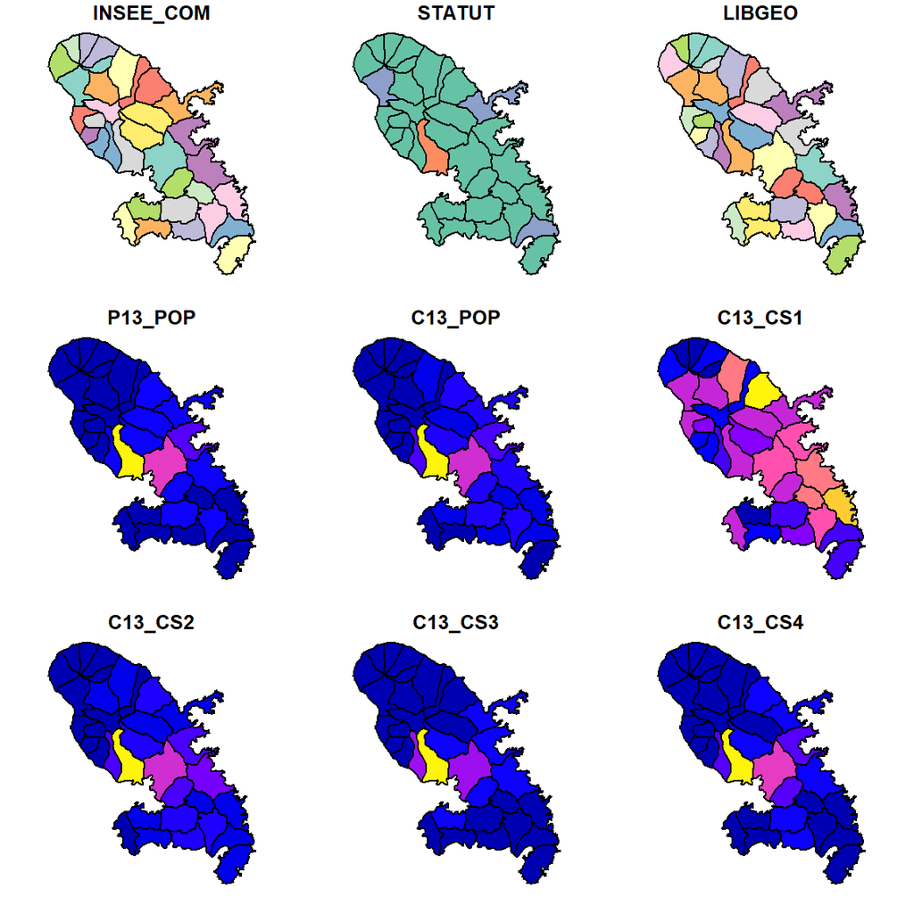

```r
plot(mtq)
```

En ne gardant que la géométrie :

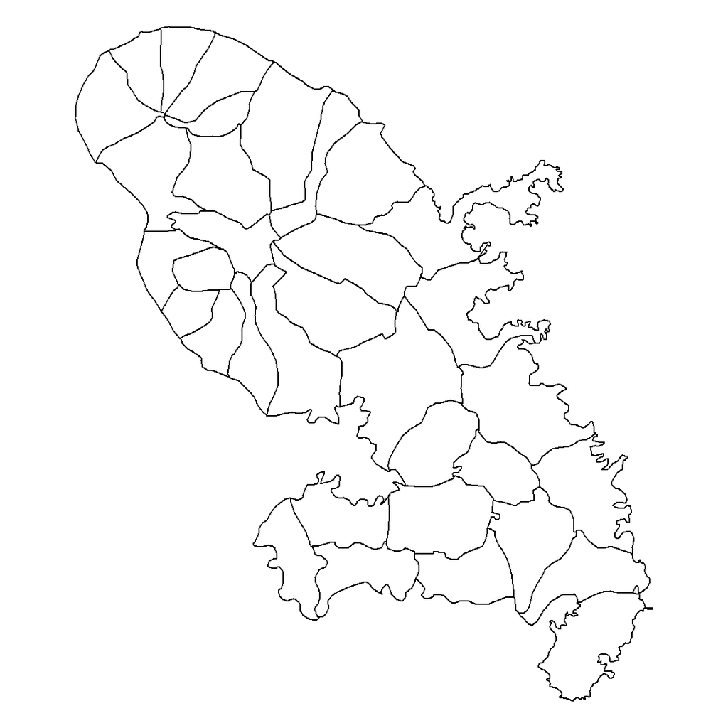

```r
plot(st_geometry(mtq))
```

### Extraire les centroïdes

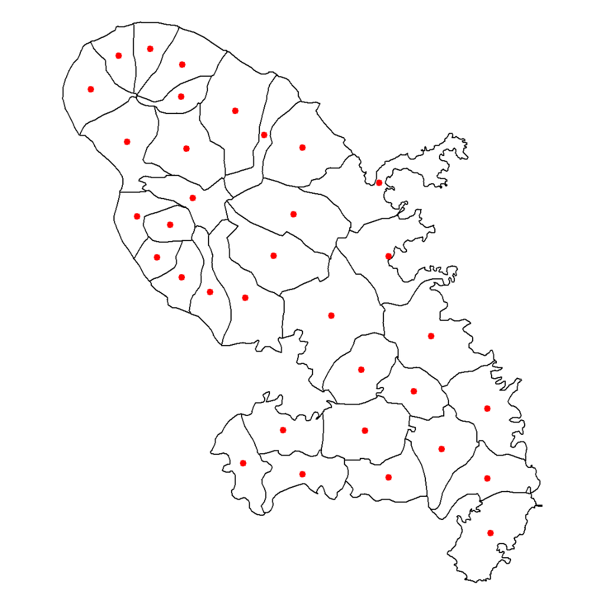

```r
mtq_c <- st_centroid(mtq)
plot(st_geometry(mtq))
plot(st_geometry(mtq_c), add=TRUE, cex=1.2, col="red", pch=20)
```

### Matrice de distance

```r
mat <- st_distance(x=mtq_c,y=mtq_c)
mat[1:5,1:5]
```

```
Units: [m]
          [,1]     [,2]      [,3]      [,4]      [,5]
[1,]     0.000 35297.56  3091.501 12131.617 17136.310
[2,] 35297.557     0.00 38332.602 25518.913 18605.249
[3,]  3091.501 38332.60     0.000 15094.702 20226.198
[4,] 12131.617 25518.91 15094.702     0.000  7177.011
[5,] 17136.310 18605.25 20226.198  7177.011     0.000
```

### Agrégation de polygones

Union simple :

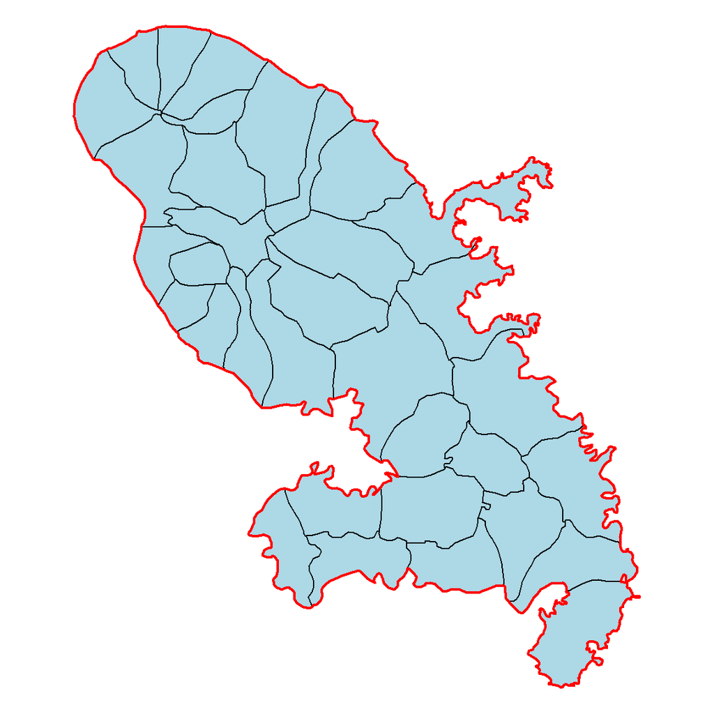

```r
mtq_u <- st_union(mtq)
plot(st_geometry(mtq), col="lightblue")
plot(st_geometry(mtq_u), add=T, lwd=2, border = "red")
```

A partir d’une variable de regroupement :

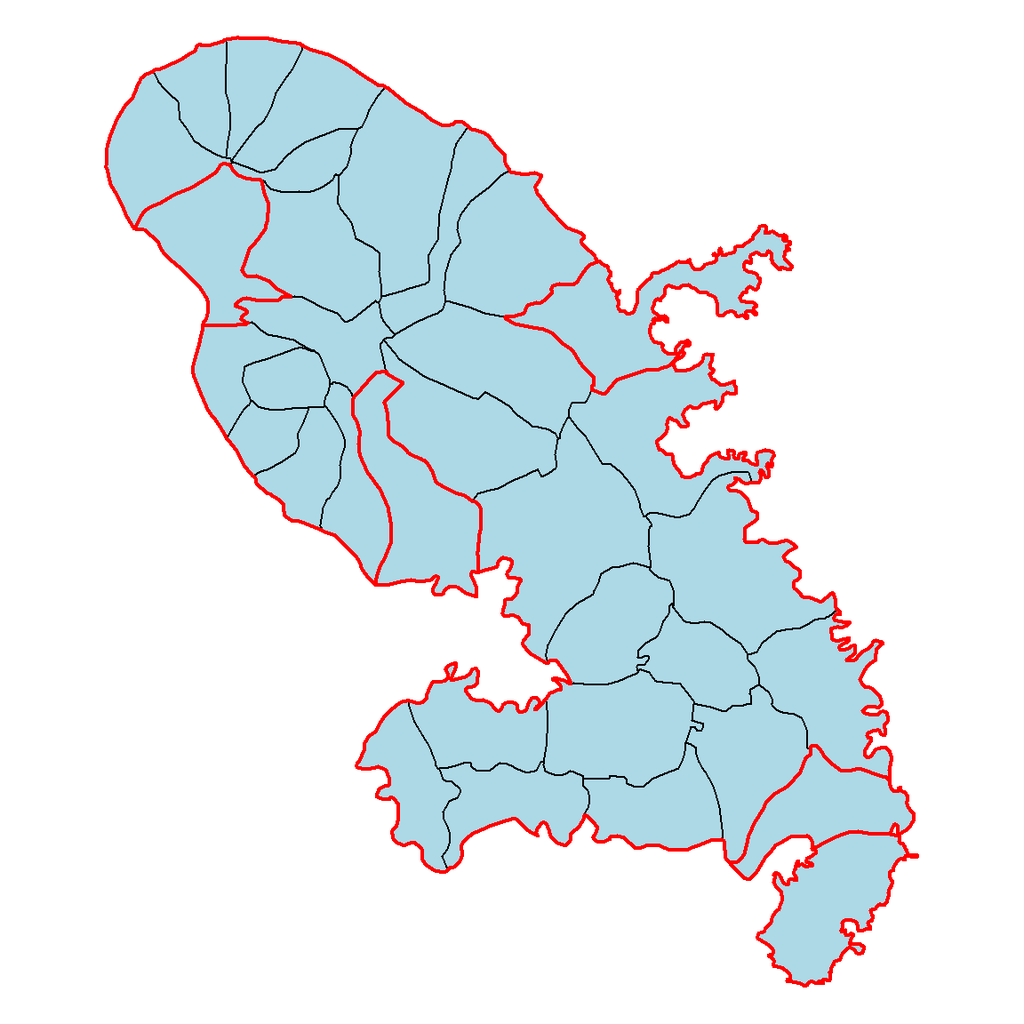

```r
library(dplyr)
mtq_u2 <- mtq %>%
  group_by(STATUT) %>%
  summarize(P13_POP = sum(P13_POP))
plot(st_geometry(mtq), col="lightblue")
plot(st_geometry(mtq_u2), add=T, lwd=2, border = "red", col=NA)
```

### Zone tampon

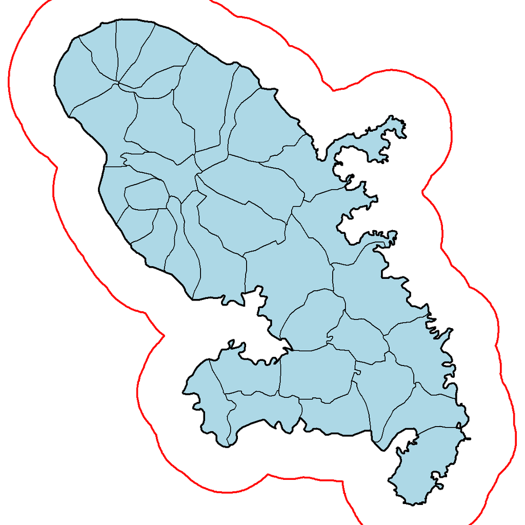

```r
mtq_b <- st_buffer(x = mtq_u, dist = 5000)
plot(st_geometry(mtq), col="lightblue")
plot(st_geometry(mtq_u), add=T, lwd=2)
plot(st_geometry(mtq_b), add=T, lwd=2, border = "red")
```

### Intersection de polygones

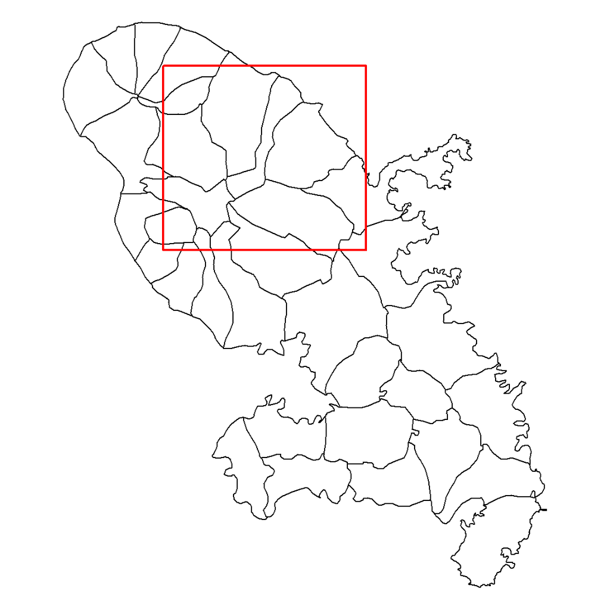

```r
# create a polygon
m <- rbind(c(700015,1624212), c(700015,1641586), c(719127,1641586),
           c(719127,1624212), c(700015,1624212))
p <- st_sf(st_sfc(st_polygon(list(m))), crs = st_crs(mtq))
plot(st_geometry(mtq))
plot(p, border="red", lwd=2, add=T)
```

`st_intersection()` extrait la partie de `mtq` qui s’intersecte avec le polygone créé.

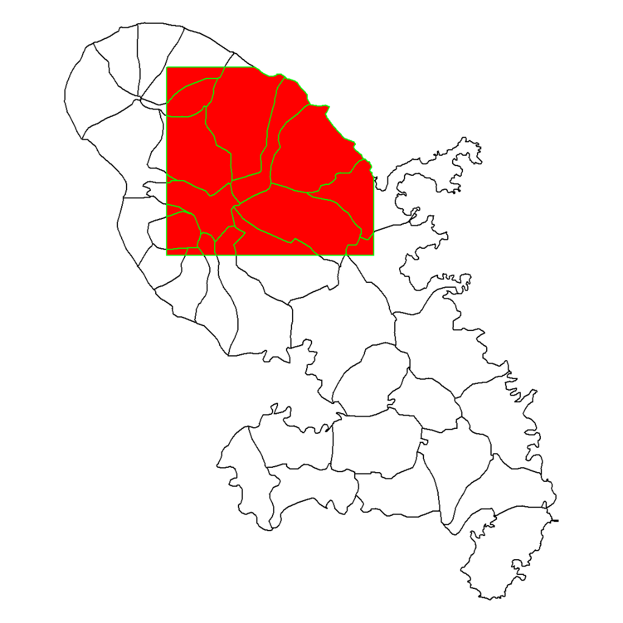

```r
mtq_z <- st_intersection(x = mtq, y = p)
plot(st_geometry(mtq))
plot(st_geometry(mtq_z), col="red", border="green", add=T)
```

### Compter les points dans des polygones

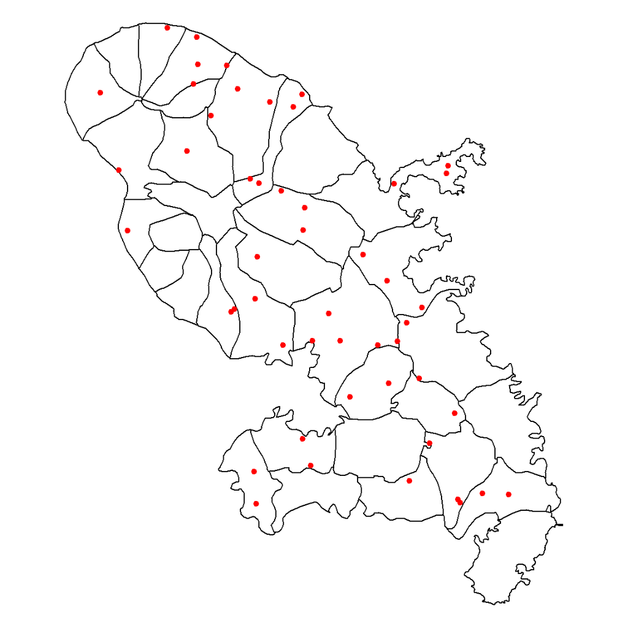

```r
pts <- st_sample(x = mtq, size = 50)
plot(st_geometry(mtq))
plot(pts, pch = 20, col = "red", add=TRUE, cex = 1)
```

`st_interects()` crée une liste de points dans chaque polygone.

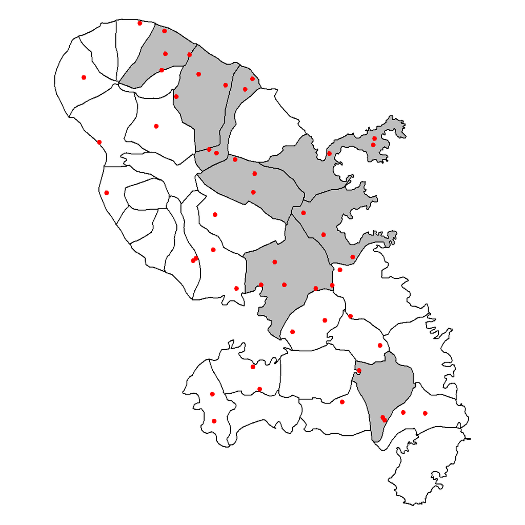

```r
inter <- st_intersects(mtq, pts)
mtq$nbpts <- sapply(X = inter, FUN = length)
plot(st_geometry(mtq))
# display munucipalities that intersect at least 2 point
plot(st_geometry(mtq[mtq$nbpts>2,]), col = "grey", add=TRUE)
plot(pts, pch = 20, col = "red", add=TRUE, cex = 1)
```

## Autres packages

[CRAN task views](https://cran.r-project.org/web/views/) permet d’avoir des informations sur les packages du CRAN pertinents pour des tâches reliées à certains sujets.

[CRAN Task View: Analysis of Spatial Data](https://CRAN.R-project.org/view=Spatial):

- Classes for spatial data
- Handling spatial data
- Reading and writing spatial data
- Visualisation
- Point pattern analysis
- Geostatistics
- Disease mapping and areal data analysis
- Spatial regression
- Ecological analysis

# Faire des cartes avec R

De nombreuses solutions existent pour faire des cartes avec R :

- `ggplot2` est un package très utilisé pour faire tous types de graphiques, et a été adapté spécifiquement aux cartes (`geom_sf`).
- Le package `tmap` contient des fonctionnalités avancées basées sur la logique de `ggplot2`
- `map_sf` (anciennement `cartography`) s’appuie sur un langage dit “base R” et permet de faire des représentations cartographiques, basiques comme avancées.
- `mapview`, `leaflet` et `mapdeck` permettent de faire des cartes interactives.

Par simplicité, nous nous concentrons ici sur `ggplot2` pour la partie statique et `mapview` pour la partie interactive.

## Petite introduction de sémiologie graphique

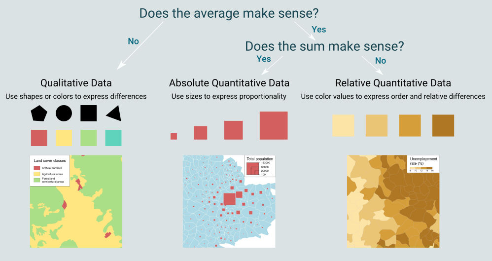

## Préparation des données

```r
library(sf)
library(dplyr)
# Import de la couche géographique (iris de Paris)
#iris.75 <- st_read(dsn = "../data/iris_75.shp",
#              stringsAsFactors = FALSE, quiet=TRUE)
iris.75 <- readRDS("../data/iris_75.RDS") %>%
  st_set_crs(2154)
head(iris.75)
```

```
Simple feature collection with 6 features and 2 fields
Geometry type: MULTIPOLYGON
Dimension:     XY
Bounding box:  xmin: 648979.6 ymin: 6861839 xmax: 654353.1 ymax: 6866159
Projected CRS: RGF93 / Lambert-93
    CODE_IRIS INSEE_COM                       geometry
78  751197316     75119 MULTIPOLYGON (((653970.6 68...
83  751176716     75117 MULTIPOLYGON (((649189.3 68...
177 751103703     75110 MULTIPOLYGON (((652767.6 68...
436 751187104     75118 MULTIPOLYGON (((652827.6 68...
468 751114314     75111 MULTIPOLYGON (((654272.9 68...
550 751103707     75110 MULTIPOLYGON (((652960.8 68...
```

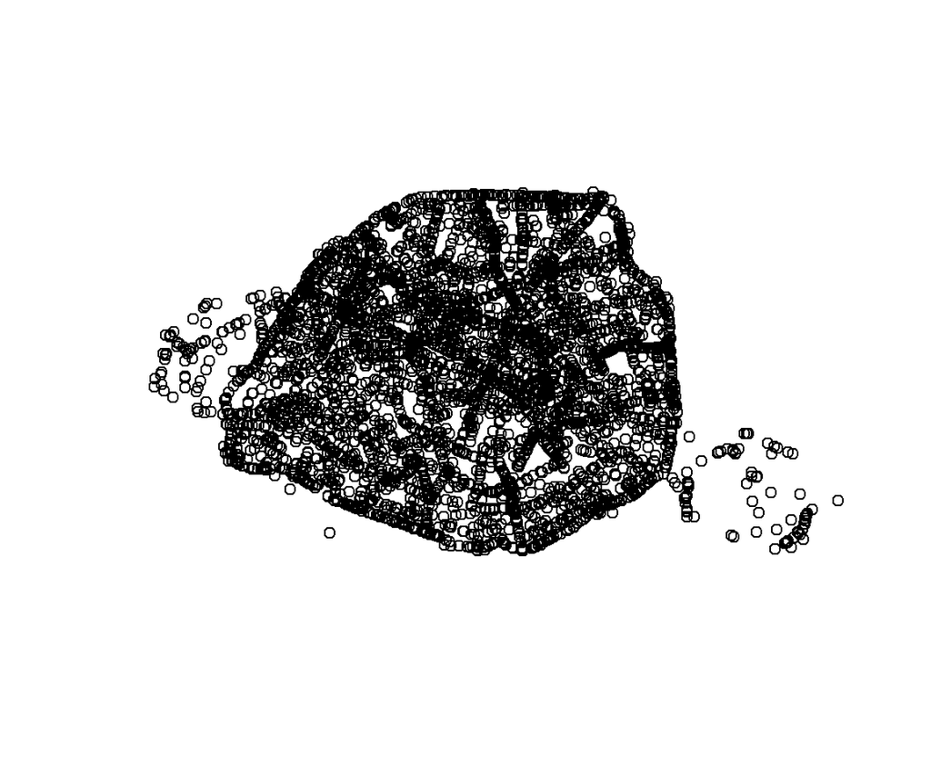

```r
# Import du dataset
accidents.2019.paris <- readRDS("../data/accidents2019_paris.RDS")
# Transformation en objet sf
accidents.2019.paris <- st_as_sf(accidents.2019.paris,
                                coords = c("long", "lat"),
                                crs = 4226, agr = "constant") %>%
  st_transform(2154)
plot(st_geometry(accidents.2019.paris))
```

```r
inter <- st_intersects(iris.75, accidents.2019.paris)
inter_blessgravtues <- st_intersects(iris.75, accidents.2019.paris
                              %>% filter(grav%in%c(2,3)))
iris.75$nbacc <- sapply(X = inter, FUN = length)
iris.75$nbacc_blessgravtues <- sapply(X = inter_blessgravtues, FUN = length)

#Il manque 24 accidents
nrow(accidents.2019.paris)-sum(iris.75$nbacc)
```

```
[1] 24
```

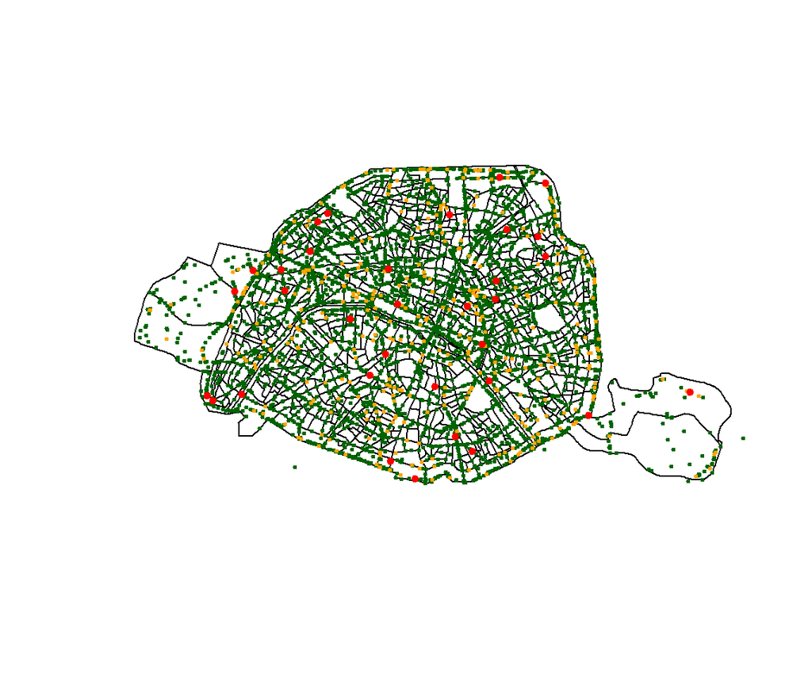

```r
plot(st_geometry(iris.75))
plot(accidents.2019.paris %>% filter(grav%in%c(1,4)) ,
     pch = 20, col = "darkgreen", add=TRUE, cex = 0.5)
plot(accidents.2019.paris %>% filter(grav%in%c(3)) ,
     pch = 20, col = "orange", add=TRUE, cex = 0.5)
plot(accidents.2019.paris %>% filter(grav==2),
     pch = 20, col = "red", add=TRUE, cex = 1)
```

## Cartes interactives `mapview`

Les cartes interactives ne sont pas forcément très pertinentes pour représenter des informations géostatistiques.

En revanche, elles sont utiles pour explorer les bases de données. Voyons un exemple avec `mapview` concernant les accidents mortels à Paris en 2019.

```r
#remotes::install_github("r-spatial/mapview")
library(mapview)
# construire une carte avec certaines options pour les cercles
# avec mapview la taille des cercles reste constante quel que soit le zoom.
# grav = 2 : individus tués
mapview(accidents.2019.paris %>%
          filter(grav==2))
```

[interactive chart not shown]

On customise un peu…

```r
mapview(accidents.2019.paris %>%
          filter(grav==2),
        map.types = "Stamen.TonerLite", legend=FALSE,
        cex=5, col.regions="#217844", lwd=0, alpha=0.9)
```

[interactive chart not shown]

On customise encore un peu plus…

```r
mapview(accidents.2019.paris %>%
          filter(grav==2) %>%
          mutate(age=2019-an_nais),
        map.types = "Stamen.TonerLite", legend=FALSE,
        cex="age", zcol="sexe", lwd=0, alpha=0.9)
```

[interactive chart not shown]

## Cartes statiques `ggplot2`

### customiser avec `osmdata`

`osmdata` permet d’extraire des éléments de la base de données gratuite et open-source OpenStreetMap.

```r
library(osmdata)
# Récupérer les routes principales grâce à osm
bb      <- iris.75 %>% st_transform(4326) %>% st_bbox()
q       <- opq(bbox = bb,timeout = 180)
qm      <- add_osm_feature (q, key = 'highway',value = 'motorway', value_exact = FALSE)
qt      <- add_osm_feature (q, key = 'highway',value = 'trunk', value_exact = FALSE)
qp      <- add_osm_feature (q, key = 'highway',value = 'primary', value_exact = FALSE)

motorway<- osmdata_sf(qm)
trunk   <- osmdata_sf(qt)
primary <- osmdata_sf(qp)

roads    <- c(primary,trunk,motorway)$osm_lines %>% st_transform(st_crs(iris.75))
roads.geom = st_intersection(st_geometry(roads),iris.75)

# Récupérer le shape de la seine
qr <- q %>%
  add_osm_feature (key = 'waterway') %>%
  add_osm_feature(key = "name:fr", value = "La Seine")
river <- osmdata_sf(qr)
river.geom <- st_geometry(river$osm_lines %>% filter(name.fr == "La Seine")) %>%
  st_transform(st_crs(iris.75))

# Export road and river layers to shapefile
st_write(roads.geom, dsn = "data/osmdata/road.shp")
st_write(river.geom, dsn = "data/osmdata/river.shp")
```

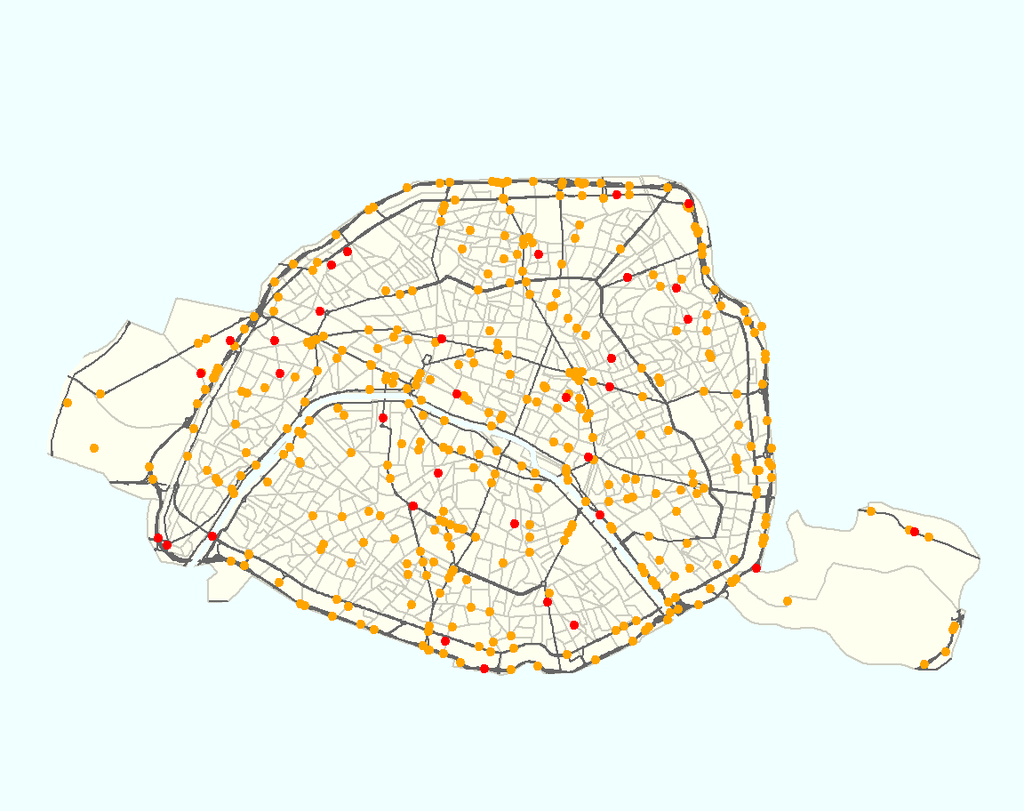

```r
# bbox est utilisé pour centrer sur Paris
bb <- st_bbox(iris.75)
par(mar=c(0.2,0.2,1.4,0.2), bg="azure")
plot(st_geometry(iris.75), col = "ivory", border="ivory3",
     xlim = bb[c(1,3)], ylim =  bb[c(2,4)])
plot(st_geometry(roads.geom),col="#666666",lwd = 1.2,add=TRUE)
plot(st_geometry(river.geom),col="azure",lwd = 3,add=TRUE)
plot(accidents.2019.paris %>% filter(grav==3) , pch = 20, col = "orange", add=TRUE, cex = 1)
plot(accidents.2019.paris %>% filter(grav==2) , pch = 20, col = "red", add=TRUE, cex = 1)
```

### Cartes avec ronds proportionnels

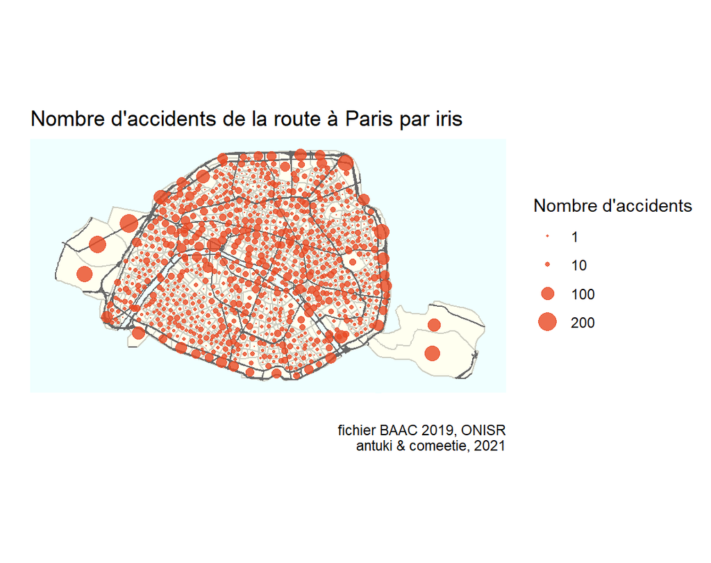

```r
library(ggplot2)
ggplot() +
  geom_sf(data = iris.75,colour = "ivory3",fill = "ivory") +
  geom_sf(data = river.geom, colour = "azure",size=2) +
  geom_sf(data = roads.geom, colour = "#666666",size=0.5) +
  geom_sf(data = iris.75 %>%  st_centroid(),
          aes(size= nbacc), colour="#E84923CC", show.legend = 'point') +
  scale_size(name = "Nombre d'accidents",
             breaks = c(1,10,100,200),
             range = c(0,5)) +
  coord_sf(crs = 2154, datum = NA,
           xlim = st_bbox(iris.75)[c(1,3)],
           ylim = st_bbox(iris.75)[c(2,4)]) +
  theme_minimal() +
  theme(panel.background = element_rect(fill = "azure",color=NA)) +
  labs(title = "Nombre d'accidents de la route à Paris par iris",
       caption = "fichier BAAC 2019, ONISR\nantuki & comeetie, 2021",x="",y="")
```

### Cartes avec choroplethes

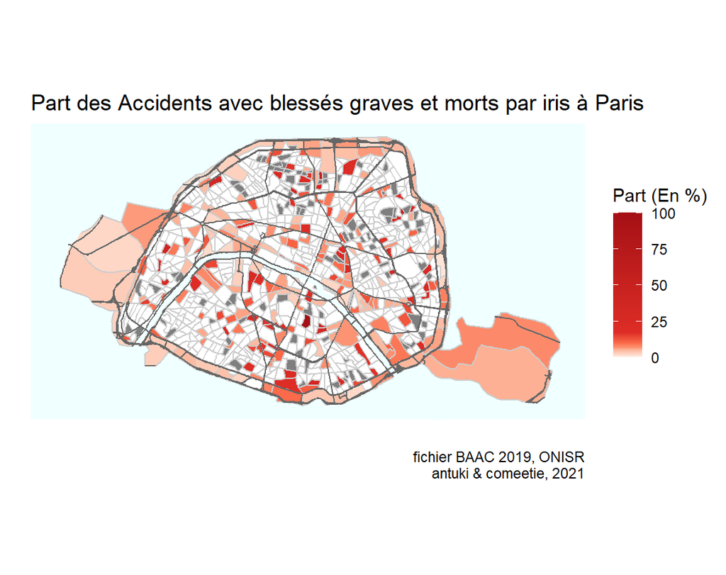

```r
library(RColorBrewer)
bks <- c(0,round(quantile((100*iris.75$nbacc_blessgravtues/iris.75$nbacc)[iris.75$nbacc_blessgravtues!=0], na.rm=TRUE, probs=seq(0,1,0.2)),0))
pal <- c("#FFFFFF",brewer.pal(length(bks)-1,"Reds"))

ggplot() +
  geom_sf(data = iris.75,colour = "ivory3",fill = "ivory") +
  geom_sf(data = iris.75, aes(fill = 100*nbacc_blessgravtues/nbacc), colour = "grey80") +
  geom_sf(data = river.geom, colour = "azure",size=2) +
  geom_sf(data = roads.geom, colour = "#666666",size=0.5) +
   scale_fill_gradientn(name = "Part (En %)",
                       values=bks/max(bks),
                       colours = pal) +
  coord_sf(crs = 2154, datum = NA,
           xlim = st_bbox(iris.75)[c(1,3)],
           ylim = st_bbox(iris.75)[c(2,4)]) +
  theme_minimal() +
  theme(panel.background = element_rect(fill = "azure",color=NA)) +
  labs(title = "Part des Accidents avec blessés graves et morts par iris à Paris",
       caption = "fichier BAAC 2019, ONISR\nantuki & comeetie, 2021", x="",y="")
```

# Crédits et reproductibilité

Présentation faite grâce au package `rmdformats`.

Elle s’inspire très fortement, ainsi que son tutoriel, d’une [précédente formation](https://github.com/comeetie/satRday) donnée par les mêmes auteurs avec Timothée Giraud.